# R Notebook

# Unsupervised Learning

The focus of all the previous chapters in this exam have been on supervised learning. This chapter will focus on unsupervised learning. With unsupervised learning we have no dependent variable so our goal is no longer to make predictions, instead our focus is finding relationships that exist within our data.

# Clustering Methods

This exam will focus on the two clustering methods of K-Means Clustering and Hierarchical Clustering. The goal of both these algorithms is to group observations in our data set based on similarities, however the way these two algorithms go about grouping the observations is very different. An example of when k-means clustering might be used is when trying to send the right coupons to certain shoppers based on spending habits. Hierarchical clustering could be used in the exploratory data analysis in order to detect outliers.

# K-Means Clustering

K-means clustering works by grouping observations into a pre-specified number of groups, k. The goal of k-means clustering is to group observations in a way that minimizes the within-cluster variation, which is just how much the observations of a group differ from each other.

This within-cluster variation can be calculated using the squared euclidean distance.

$W(C_{k}) = \frac{1}{|C_{k}|} \sum_{i,i^{'}\in C_{k}} \sum_{j=1}^{p} (x_{ij}-x_{i^{'}j})^{2}$

## How it Works

K-means clustering starts by randomly assigning each observation in the data set to one of the k groups. It then assigns a centroid for each group, which is the value in the center of the points of that group and also the point that creates the smallest within-cluster variation. For all subsequent iterations it reassigns observations to the nearest centroid, and then finds the new centroids for the reassigned observations. After each iteration the total within cluster variation will decrease, if it does not decrease or the total number of iterations set is reached, the algorithm ends.

This process ultimately creates local minimums, which means the algorithm might not end up at the best feasible solution for grouping. In order to counter this the algorithm should be run multiple times. Whichever grouping resulted in the lowest total within cluster variation should be chosen as the final model.

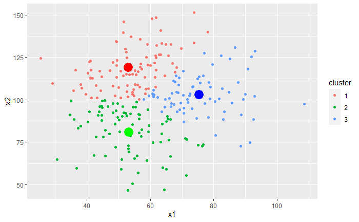

In the plot above there are three different groups, or k=3. The large dots represent the centroids of their respective categories.

# Hierarchical Clustering

Hierarchical clustering does not require a pre-specified number of groups like in k-means clustering. However, the observations are still grouped by their similarities using euclidean distance. After completing the algorithm we are left with a dendrogram.

## Dendrogram

A dedrogram is a visual representation of the groupings of our data. Its shape resembles that of an upside down tree. Observations start from the bottom as individual leafs. They are then grouped together based off which observation is the most similar.

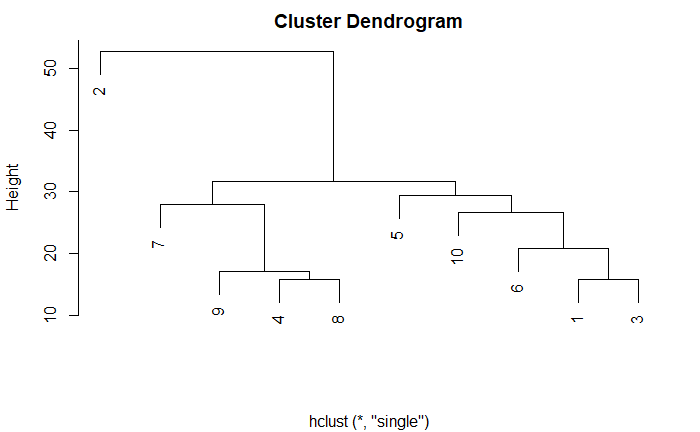

[figure not shown]

From the dendrogram above we can see the two most similar observations are 4 and 8, and 1 and 3. This is because they are fused at the lowest heights.

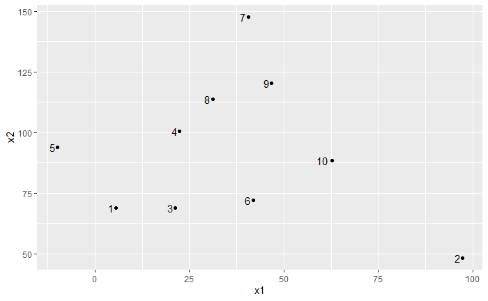

We can all see this in a scatter plot where observations 1 and 3, and observations 4 and 8 are nearest to each other.

The ultimate goal of hierarchical clustering to splits our data into clusters. After the dendrogram has been completed the clusters can be created by creating a horizontal cut in our dendrogram. For instance, if the cut was made at the height of about 30 (y-axis value of 30), there would be three clusters:

cluster 1: observations (2)

cluster 2: observations (7,9,4,8)

cluster 3: observations (5,10,6,1,3)

The number of clusters we can create ranges from 1, meaning we used no cuts, to the number of observations, meaning we cut at height 0. The height at which we choose our cut can be arbitrary. Looking at our dendrogram above the number of groups I believe we should form would be two or three.

## Forming our Dendrogram

In order to start forming our dendrogram we must first decide which similarity measure we will use, which is generally either Euclidean Distance or correlation-based distance, and which linkage to use, which is how we apply our similarity measurement between two groups of observations.

**Similarity Measures:**

Euclidean Distance: $\sqrt{\sum_{i=1}^{n} (q_{i}-p_{i})^{2}}$

correlation-based - Chooses similarity based off how correlated the features are.

**4 Linkage Choices:**

Complete - Uses the largest pairwise dissimilarity between the two groups.

Single - Uses the smallest pairwise dissimilarity between two groups.

Average - Uses the average pairwise dissimilarity between two groups.

Centroid - Uses the distance between the centroids of two groups.

In order to identify which linkage function was used from a dendrogram, average and complete linkages tend to create more balanced dendrograms, while single linkage tends to create unbalanced dendrograms. Centroid linkage can lead to inversion, where a cluster is formed below the individual clusters in a dendrogram.

Once we have chosen our similarity measure and linkage function we can begin fusing our observation one by one. This means checking every possible combination of groupings and fusing at the one that creates the smallest value if euclidean distance is used, or largest value if the correlation-based measure is used, for whichever linkage function is chosen. This process continues until all observations are grouped together.

# Problems with Clustering Methods

For K-means clustering we must decide how many clusters to choose and whether or not to standardize the data. Whichever option we choose can drastically change our results.

For hierarchical clustering we must choose which similarity measure, which linkage function to use, where to group our data, and whether or not to standardize our data.

Generally we can try several different approaches and choose the one that ultimately creates the most useful solution.